# Homework 2: Analyzing genetic variance in the UCP1 gene of vervet monkeys using PCA and DAPC

Becca DeCamp, Christian Gagnon, Mel Zarate

3/8/2019

R version: 3.5.2 “Egshell Igloo”  
vcfR version: 1.8.0  
adegenent version: 2.1.1  
ggplot2 version: 3.1.0

## Introduction: UCP1 and PCA/DAPC.

For these analyses, we decided to focus on just the UCP1 gene from our vervet genomic data (courtesy of the International Vervet Research Consortium), because it is a point of research interest in our lab. UCP1 is one among a family of genes responsible for the production of uncoupling proteins, and assists in non-shivering thermogenesis (NST). UCP1 mediated thermogenesis is one of the critical adaptive physiological mechanisms which led to the evolution and radiation of homeothermic ancestral eutherian mammals. Vervet monkeys are amongst the most widely distributed nonhuman primates and have high phenotypic diversity. Our sample of *Chlorocebus* covers a wide longitudinal range with dramatically different climatic conditions.

For our analysis, we used Principal Component Analysis (PCA) and Discriminant Analysis of Principal Coordinates (DAPC). We discuss the differences we found between these two analyses in our conclusion.

## Analysis

We will analyze our data in four different ways using PCA and DAPC. First, we will use these methods to look at VCF data of the whole UCP1 gene from samples of all vervet species and group them by taxa. Second, we will use these methods to look at VCF data of the whole UCP1 gene in the *Chlorocebus pygerythrus* species and group them by region. Third, we will use these methods to look at VCF data of the whole UCP1 gene in the *Chlorocebus pygerythrus* species and group them by minimum temperature. Finally, we will use these methods to look at VCF data of only the SNPs out of HWE in UCP1 in the *Chlorocebus pygerythrus* species and group them by region.  
The research questions we asked in this analysis are: * Is there genetic differences between the UCP1 gene in different species of vervet monkey? * Are there regional differences between the UCP1 gene in the pygerythrus species of vervet monkey?

Here are the packages we need for our analyses.

```r
library(vcfR)
library(adegenet)
```

```r
library(ggplot2)
```

### General PCA of UCP1 in all vervet species

This analysis is looking at UCP1 population structure in all species of vervet, and is grouped by taxon. We did this as our initial analysis because we wanted to get a sense of the genetic variation within the UCP1 region in vervets.  
Here’s how to make the objects we need. We need both genlight (for PCA) and genind (for DAPC) objects, which we make using functions from the vcfR package. We also need to assign population variables to the files which is where the vervet.population.panel comes in. This is a tab-deliminated text file which we read in as a table.

```r
#vervet VCF for UCP1 (Christian misspelled this file, it is UCP not UPC)
vervet <- read.vcfR("ALL_UPC1.vcf", verbose = TRUE)
```

```
## Scanning file to determine attributes.
## File attributes:
##   meta lines: 38
##   header_line: 39
##   variant count: 444
##   column count: 172
##
Meta line 38 read in.
## All meta lines processed.
## gt matrix initialized.
## Character matrix gt created.
##   Character matrix gt rows: 444
##   Character matrix gt cols: 172
##   skip: 0
##   nrows: 444
##   row_num: 0
##
Processed variant: 444
## All variants processed
```

```r
#creating genind
vervet_genind <- vcfR2genind(vervet, sep = "[|/]")

#population data read in
pop.data <- read.table("vervet.population.panel", sep = "\t", header = TRUE)

#Checking that all the samples in the VCF and the population data frame are included. Should be TRUE.

all(colnames(vervet@gt)[-1] == pop.data$AccessID)
```

```
## [1] TRUE
```

```r
#assigning pop data to genind

pop(vervet_genind) <- pop.data$taxon


#genlight object for PCA

vervet_genlight <- vcfR2genlight(vervet)

#assigning pop data to genlight
pop(vervet_genlight) <- pop.data$taxon
```

This chunk does a PCA with the genlight object. We used nf=2 becuase our eigenvalues indicate this is the best number of PCs to keep. Our graph of eigenvalues will illustrate our decision.

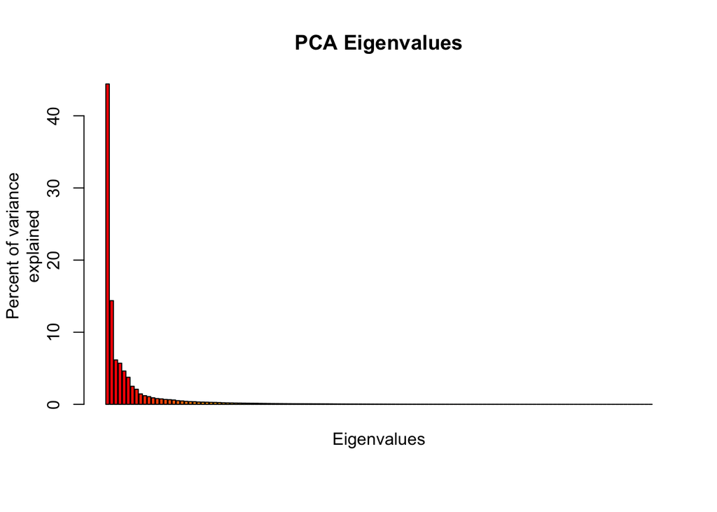

```r
pca <- glPca(vervet_genlight, nf = 2)
#Here's a graph of the eigenvalues (or, the principle components). This graph shows how much of the variation of the original dataset is kept with the PCA. This graph was used to determine the number of PCs to keep

barplot(100*pca$eig/sum(pca$eig), col = heat.colors(50), main="PCA Eigenvalues")
title(ylab="Percent of variance\nexplained", line = 2)
title(xlab="Eigenvalues", line = 1)
```

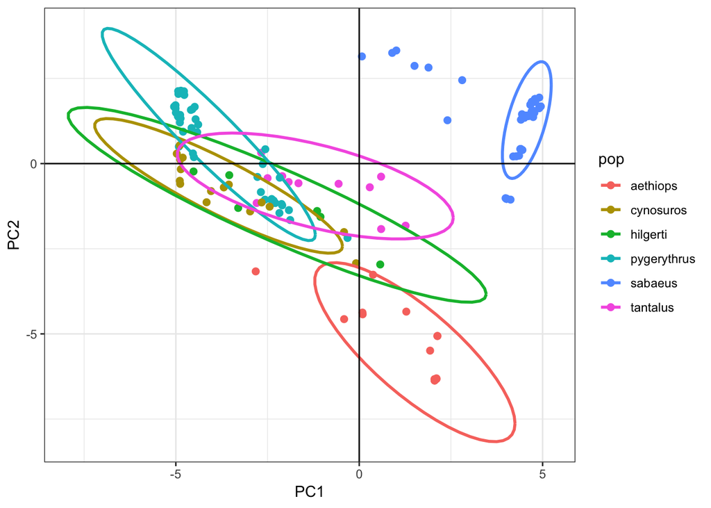

```r
#Now, we can graph the results with ggplot!

#Creating a dataframe with pca scores, and assigning population data
pca.scores <- as.data.frame(pca$scores)
pca.scores$pop <- pop(vervet_genlight)

#ggplot

p <- ggplot(pca.scores, aes(x=PC1, y=PC2, colour=pop)) + geom_point(size=2) + stat_ellipse(level = 0.95, size = 1) + geom_hline(yintercept = 0) + geom_vline(xintercept = 0) + theme_bw()
p
```

```r
#Ignore the warning error. We see here that there are some outliers in our data. Will the DAPC show the same thing?
```

DAPC analysis using genind object

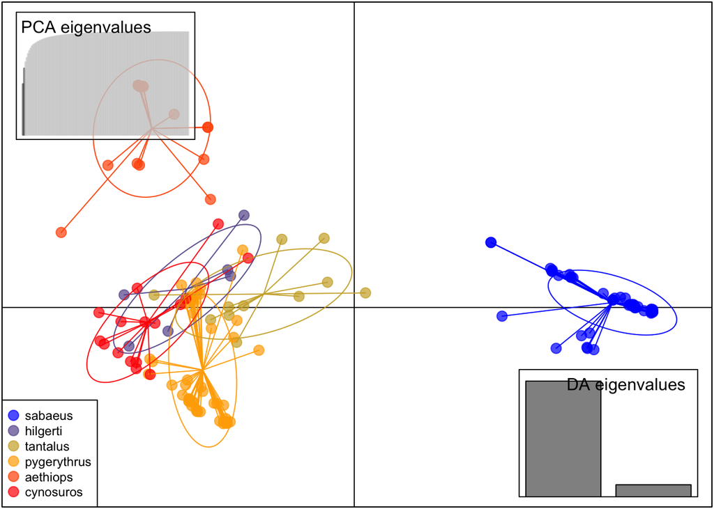

```r
#Like the PCA, the first two PCs best explain the data. Therefore, we retain only these PCs.
dapc <- dapc(vervet_genind, n.pca = 2, n.da = 2)

#Plotting
scatter(dapc, cex = 2, legend = TRUE, clabel = F, posi.leg = "bottomleft", scree.pca = TRUE,
        posi.pca = "topleft", cleg = 0.75)
```

```r
#We see the same two taxa as outliers in our DAPC.
```

We see that the DAPC and PCA are similar; Most of the species of vervet cluster together, but there are a few genetically outlying species like *sabaeus* and *aethiops*.

### PCA and DAPC using just the *Chlorocebus pygerythrus* species UCP1, clustering by region.

As said in the introduction, we are interested in looking at UCP1 structure in *Chlorocebus pygerythrus* because this species is our primary species of study in our research. Here we will use PCA and DAPC to look at genetic variation in just *pygerythrus*, and group them by the region their study sites are in.  
In this Pygerythrus only PCA which, included limited climate data, 2 PCs explained approximately 65 percent of the diffrences as well.

```r
#pygerythrus VCF for UCP1; we isolated this population using our Linux pipeline.
pyg <- read.vcfR("pyg_UCP1.vcf.gz", verbose = TRUE)
```

```
## Scanning file to determine attributes.
## File attributes:
##   meta lines: 39
##   header_line: 40
##   variant count: 285
##   column count: 60
##
Meta line 39 read in.
## All meta lines processed.
## gt matrix initialized.
## Character matrix gt created.
##   Character matrix gt rows: 285
##   Character matrix gt cols: 60
##   skip: 0
##   nrows: 285
##   row_num: 0
##
Processed variant: 285
## All variants processed
```

```r
#genind object
pyg_genind <- vcfR2genind(pyg, sep = "[|/]")

#population data (we modified our population dataset, which is why we need to read it in again)
pyg.data <- read.table("pygerythrus.population.panel", sep = "\t", header = TRUE)

#Checking that all the samples in the VCF and the population data frame are included

all(colnames(pyg@gt)[-1] == pyg.data$AccessID)
```

```
## [1] TRUE
```

```r
#assigning pop data to genind

pop(pyg_genind) <- pyg.data$region


#genlight object for PCA

pyg_genlight <- vcfR2genlight(pyg)

#assigning pop data to genlight
pop(pyg_genlight) <- pyg.data$region
```

This chunk does a PCA with the genlight object. We used nf=2 becuase our eigenvalues indicate that only one PC is adequate to explain our data, but we kept 2 to err on the conservative side. Our graph of eigenvalues will illustrate our decision.

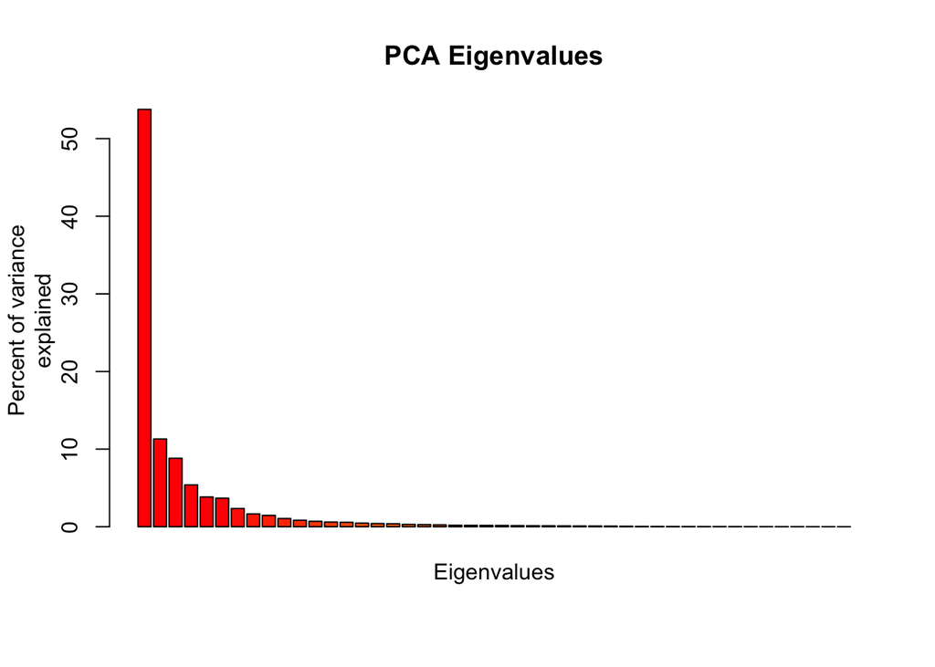

```r
pca1 <- glPca(pyg_genlight, nf = 2)
#Here's a graph of the eigenvalues (or, the principle components). This graph shows how much of the variation of the original dataset is kept with the PCA.

barplot(100*pca1$eig/sum(pca1$eig), col = heat.colors(50), main="PCA Eigenvalues")
title(ylab="Percent of variance\nexplained", line = 2)
title(xlab="Eigenvalues", line = 1)
```

```
## Too few points to calculate an ellipse
## Too few points to calculate an ellipse
```

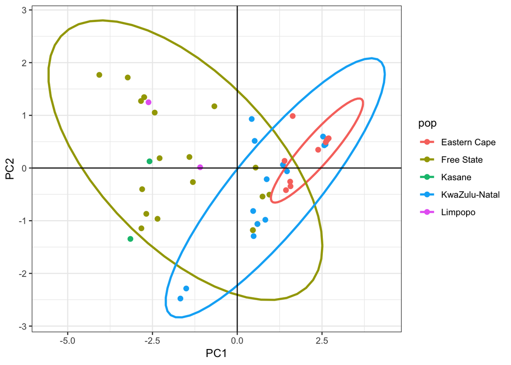

```r
#Now, we can graph the results with ggplot!

#Creating a dataframe with pca scores
pca.scores1 <- as.data.frame(pca1$scores)
pca.scores1$pop <- pop(pyg_genlight)

#ggplot

p <- ggplot(pca.scores1, aes(x=PC1, y=PC2, colour=pop)) + geom_point(size=2) + stat_ellipse(level = 0.95, size = 1) + geom_hline(yintercept = 0) + geom_vline(xintercept = 0) + theme_bw()
p
```

```r
#There is not complete overlap, but there is significant overlap between the population that reside in these regions.
```

DAPC analysis for these data, again clustered by region.

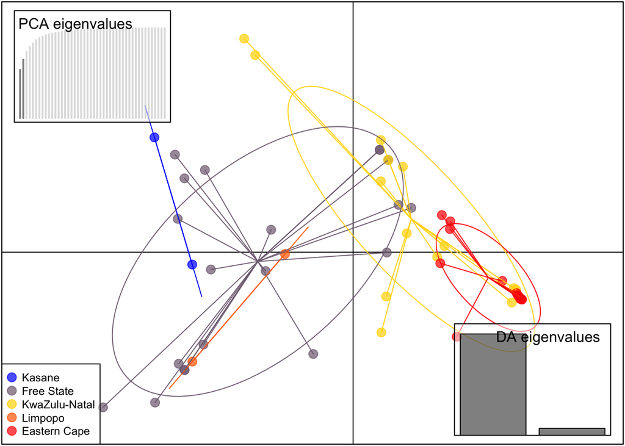

```r
#Like the PCA, the first two PCs best explain the data. Therefore, we retain only these PCs.
dapc1 <- dapc(pyg_genind, n.pca = 2, n.da = 2)

#Plotting
scatter(dapc1, cex = 2, legend = TRUE, clabel = F, posi.leg = "bottomleft", scree.pca = TRUE,
        posi.pca = "topleft", cleg = 0.75)
```

```r
#DAPC illustrates the same clustering pattern as PCA.
```

### PCA and DAPC using just the *Chlorocebus pygerythrus* species UCP1, clustering by minimum temperature at the study site.

Next, we were interested in looking at how the *Chlorocebus pygerythrus* data would cluster when grouped by minimum temperature at the study site. We were interested in this because UCP1 responds to cooler temperatures.

```r
#We already have the VCF file we need loaded and made in to the file types we need, all we need to do is change the population data category.
pop(pyg_genind) <- pyg.data$min_temp

pop(pyg_genlight) <- pyg.data$min_temp
```

PCA for this analysis. We used nf=2 becuase our eigenvalues indicate that only one PC is adequate to explain our data, but we kept 2 to err on the conservative side. Our graph of eigenvalues will illustrate our decision.

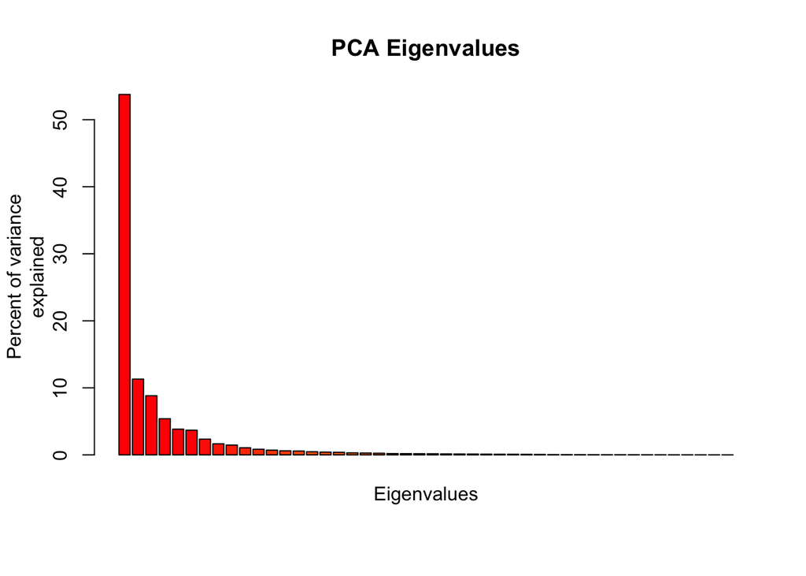

```r
pca2 <- glPca(pyg_genlight, nf = 2)
#Here's a graph of the eigenvalues (or, the principle components). This graph shows how much of the variation of the original dataset is kept with the PCA.

barplot(100*pca2$eig/sum(pca2$eig), col = heat.colors(50), main="PCA Eigenvalues")
title(ylab="Percent of variance\nexplained", line = 2)
title(xlab="Eigenvalues", line = 1)
```

```
## Too few points to calculate an ellipse
## Too few points to calculate an ellipse
## Too few points to calculate an ellipse
## Too few points to calculate an ellipse
## Too few points to calculate an ellipse
## Too few points to calculate an ellipse
```

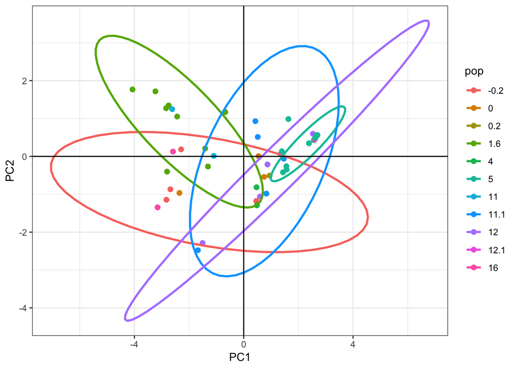

```r
#Now, we can graph the results with ggplot!

#Creating a dataframe with pca scores
pca.scores2 <- as.data.frame(pca2$scores)
pca.scores2$pop <- pop(pyg_genlight)

#ggplot

p <- ggplot(pca.scores2, aes(x=PC1, y=PC2, colour=pop)) + geom_point(size=2) + stat_ellipse(level = 0.95, size = 1) + geom_hline(yintercept = 0) + geom_vline(xintercept = 0) + theme_bw()
p
```

```r
#There is not complete overlap, but there is significant overlap between the populations that reside in regions with different minimum temperatures.
```

DAPC for this analysis.

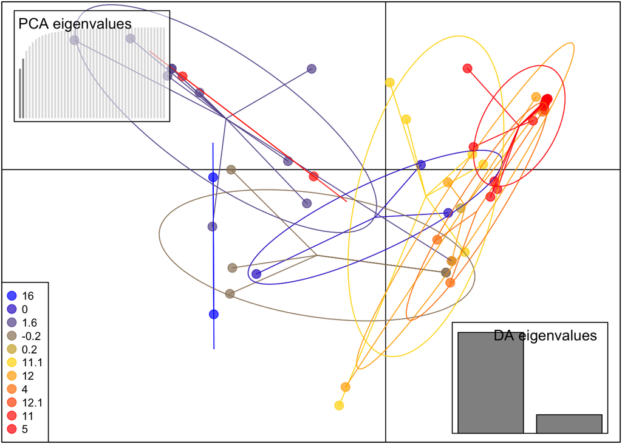

```r
#Like the PCA, the first two PCs best explain the data. Therefore, we retain only these PCs.
dapc2 <- dapc(pyg_genind, n.pca = 2, n.da = 2)

#Plotting
scatter(dapc2, cex = 2, legend = TRUE, clabel = F, posi.leg = "bottomleft", scree.pca = TRUE,
        posi.pca = "topleft", cleg = 0.75)
```

```r
#DAPC illustrates the same clustering pattern as PCA.
```

We decided not to include this part of the analysis in our final presentation. It creates too many grouping categories and some of the group only have 1 or 2 samples, which is not enough for comparison. Besides it pretty clear it is not a significant component because it didn’t change the pca after we added the temperature data.

```r
#vervet VCF for UCP1
pygHWE <- read.vcfR("pyg_UPC1_HWE.vcf.gz", verbose = TRUE)
```

```
## Scanning file to determine attributes.
## File attributes:
##   meta lines: 1638
##   header_line: 1639
##   variant count: 3061
##   column count: 60
##
Meta line 1000 read in.
Meta line 1638 read in.
## All meta lines processed.
## gt matrix initialized.
## Character matrix gt created.
##   Character matrix gt rows: 3061
##   Character matrix gt cols: 60
##   skip: 0
##   nrows: 3061
##   row_num: 0
##
Processed variant 1000
Processed variant 2000
Processed variant 3000
Processed variant: 3061
## All variants processed
```

```r
pygHWE_genind <- vcfR2genind(pygHWE, sep = "[|/]")

#Already have population data, don't need to load in again.

#Checking that all the samples in the VCF and the population data frame are included. This should be TRUE.

all(colnames(pygHWE@gt)[-1] == pyg.data$AccessID)
```

```
## [1] TRUE
```

```r
#assigning pop data to genind

pop(pygHWE_genind) <- pyg.data$region


#genlight object for PCA

pygHWE_genlight <- vcfR2genlight(pygHWE)

#assigning pop data to genlight
pop(pygHWE_genlight) <- pyg.data$region
```

Here is our PCA. We used nf=2 becuase our eigenvalues indicate that only one PC is adequate to explain our data, but we kept 2 to err on the conservative side. Our graph of eigenvalues will illustrate our decision.

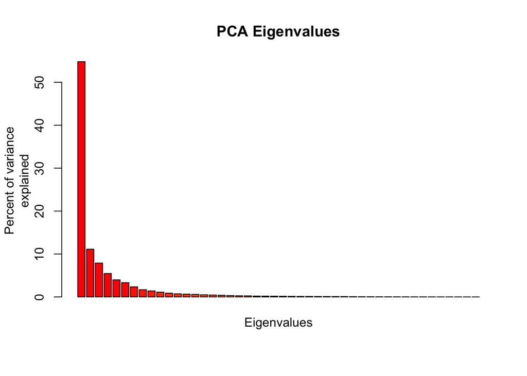

```r
pca2 <- glPca(pygHWE_genlight, nf = 2)
#Here's a graph of the eigenvalues (or, the principle components). This graph shows how much of the variation of the original dataset is kept with the PCA.

barplot(100*pca2$eig/sum(pca2$eig), col = heat.colors(50), main="PCA Eigenvalues")
title(ylab="Percent of variance\nexplained", line = 2)
title(xlab="Eigenvalues", line = 1)
```

```
## Too few points to calculate an ellipse
## Too few points to calculate an ellipse
```

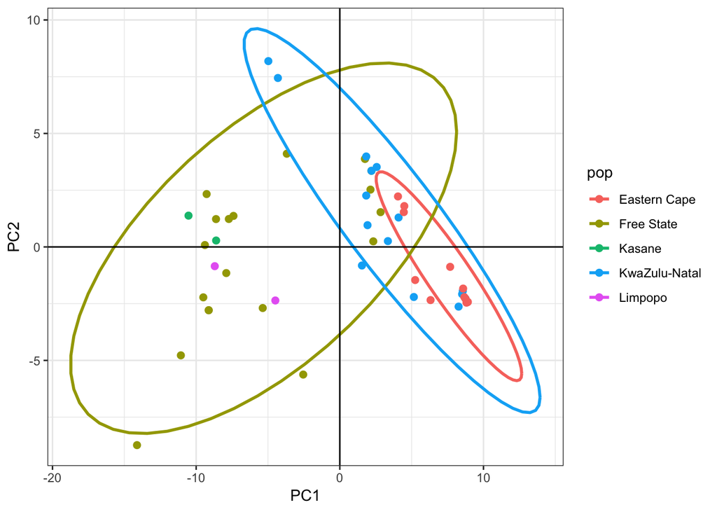

```r
#Now, we can graph the results with ggplot!

#Creating a dataframe with pca scores
pca.scores2 <- as.data.frame(pca2$scores)
pca.scores2$pop <- pop(pygHWE_genlight)

#ggplot

p <- ggplot(pca.scores2, aes(x=PC1, y=PC2, colour=pop)) + geom_point(size=2) + stat_ellipse(level = 0.95, size = 1) + geom_hline(yintercept = 0) + geom_vline(xintercept = 0) + theme_bw()
p
```

Here is our DAPC.

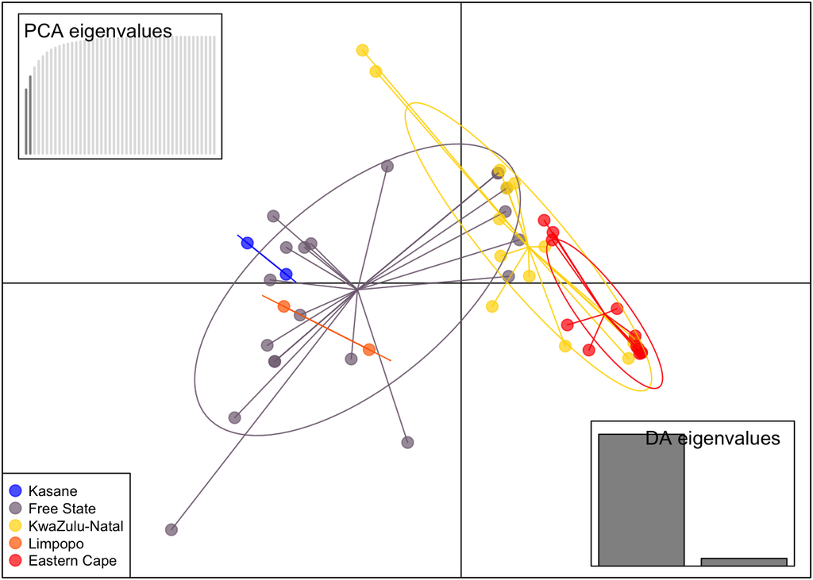

```r
#Like the PCA, the first two PCs best explain the data. Therefore, we retain only these PCs.
dapc2 <- dapc(pygHWE_genind, n.pca = 2, n.da = 2)

#Plotting
scatter(dapc2, cex = 2, legend = TRUE, clabel = F, posi.leg = "bottomleft", scree.pca = TRUE,
        posi.pca = "topleft", cleg = 0.75)
```

## Conclusions

While both methods of analysis that we used un this project are similar, there are some important differences to note. Both PCA and DAPC reduce datasets in to a couple of principal components that describe the dataset, but PCA only is concerned with the overall differences in the dataset while DAPC focuses specifically on the differences between groups. DAPC method can outperform PCA in achieving a clear variance difference between populations. DAPC methods can be applied in quality control and stratification population correction as an alternative to the PCA because of summarizing the genetic differentiation between groups and overlooking within-group variation and providing better population structure.

We see significant out groups of sabaeus and aethiops, but doesn’t tell us much about why they are different. We did not have climate data for all of the taxa, which is why we only focused on climate variables in *Chlorocebus pygerythrus*. We hope to focus more on climate variables in all species in our final project. In our analysis of *Chlorocebus pygerythrus*, we included some minimum temperature data for each of the samples sites. Although we did not find significant differences between our sites, it does appear that the individuals from the Free State sites are differentiated from the others. This warrants further investigation because temperatures in the Free State are historically lower than both the Eartern Cape and KwaZulu-Natal. There are too few samples in the Bostwana and Limpopo site to make any determination about these populations. Our final analysis of SNPs out of HWE is similar to our analysis of *Chlorocebus pygerythrus* by region, but with stronger variance shown between regions in DAPC. THe shape of DAPC is more consistent than PCA with the “by region” plots that look at all of UCP1.